# Investigation of multi-trait EBMF program correspondence

This vignette extends the single-trait investigation (`investigation-univariate-analysis.html`) to **multiple traits**, and asks one question: **which programs are shared between traits, which SNPs carry them, and do those SNPs push the traits the same way or opposite ways?**

The default set runs this on real data with a strong, independently published prior to check against: the T2D GWAS upload from Suzuki T2D (GUID `c6d2e20f-6ece-d093-78ee-37534547c466`), whose high/medium programs turned out unusually clean, alongside three more specific metabolic traits rather than BMI – whose own background is dominated by dozens of body-size traits that move with it almost everywhere (see Investigation of univariate analysis) and so needs more care than a first cross-trait check calls for. Every cross-trait pair of programs is scored, from however many traits are supplied: triglyceride levels (1631), HDL cholesterol (1630) and HbA1c (1640), each paired with T2D and with each other. Suzuki et al.’s own cluster profiles give concrete expectations to check the links against (Suzuki T2D, Part 5):

- **Triglycerides** should link to T2D’s Lipodystrophy and Metabolic syndrome programs (P2, P6, P10, P24, P31, P35, P47 in the T2D-only fit) and be mostly **concordant**, but with a possible **antagonistic** TM6SF2-type liver locus – the one place a single partner trait is expected to show both directions at once.
- **HDL cholesterol** should link to the same Lipodystrophy/Metabolic syndrome programs, **antagonistically** (the T2D risk allele lowers HDL).
- **HbA1c** should link to T2D’s beta-cell and Residual glycaemic signal instead – a different part of the partition from the lipid traits, and the only one of the three expected to touch T2D’s glycaemic core directly.

EBMF programs are discovered independently for each target trait, so each trait’s architecture is described in its own terms first. Every cross-trait pair of programs is then asked two questions. **Same biology?** – are the two programs driven by the same background traits in the same proportions (profile congruence of their trait loadings, `L_pm`)? **Same SNPs?** – where the two traits carry the same fine-mapped loci, do the programs load on them alike (alignment of their SNP loadings, `F_pm`)? The answers are combined into high / medium / low tiers; high- and medium-tier pairs are **links**, and links are grouped into **multi-trait families**, each with the set of loci its programs claim. The **direction** of a link – whether the alleles involved raise both traits or raise one and lower the other – comes from the sign of the profile congruence and, where enough loci are shared, from `module_rg()`, the correlation of the traits’ own allele effects.

Traits are supplied as an array in `params$trait_ids`. We use **2DGGI GWAS EUR ancestry meta-analysis** (trait id c6d2e20f-6ece-d093-78ee-37534547c466), **Triglyceride levels** (trait id 1631), **HDL cholesterol levels** (trait id 1630), **Haemoglobin A1c levels** (trait id 1640).

Active run parameters

| api | trait_ids | trait_subset | min_snp_signals | min_module_size | compress_method | compress_scale | include_trans | similarity_threshold | ebmf_lfsr_threshold | ebmf_magnitude_threshold | ebmf_prior | ebmf_backfit | min_mean_internal | min_connectedness | n_null | n_rep | n_perm | fdr_threshold | phi_high | phi_low | min_alignment | min_eff_loci | min_shared_loci | mutual_best | associations |
| --- | --- | --- | --- | --- | --- | --- | --- | --- | --- | --- | --- | --- | --- | --- | --- | --- | --- | --- | --- | --- | --- | --- | --- | --- | --- |
| production | c6d2e20f-6ece-d093-78ee-37534547c466, 1631, 1630, 1640 | phenotypic | 2 | 3 | asinh | 5 | TRUE | 0.2 | 0.02 | 0.5 | point_laplace | TRUE | 0.3 | 0.5 | 5 | 2 | 3000 | 0.05 | 0.85 | 0.7 | 0.5 | 5 | 3 | FALSE | coloc |

Target traits compared

| trait_id | trait_name |
| --- | --- |
| c6d2e20f-6ece-d093-78ee-37534547c466 | 2DGGI GWAS EUR ancestry meta-analysis |
| 1631 | Triglyceride levels |
| 1630 | HDL cholesterol levels |
| 1640 | Haemoglobin A1c levels |

## Step 1: Univariate EBMF per trait

The existing single-trait pipeline is run independently for each target trait: `run_univariate_clustering()` (EBMF) followed by `summarise_ebmf_programs()`. Programs of high or medium confidence are kept (not low or single_trait). Each program’s posterior-mean SNP loadings (`F_pm`), lFSR, and high-confidence SNP membership are then extracted, with loadings sign-oriented to the target trait (see `extract_program_loadings()`).

Each anchor trait has its own list of **duplicate traits**, removed before fitting: other GWAS of the same measurement (and, for T2D, diagnosis, treatment, family-history and complication traits that repeat the T2D row at every SNP, the same list as in Suzuki T2D). A duplicate of the anchor is positive at almost every one of its SNPs after orientation, so it adds the same component to every SNP’s profile and hides the programs that actually differ between SNPs (see BMI for what that costs).

The same lists are passed to the cross-trait comparison as `exclude_features`: a trait listed for either anchor is left out of every profile comparison involving that anchor, including the partner’s fit, where it is an ordinary background trait. Without that, a TG duplicate sitting in the HDL fit could carry a TG ~ HDL profile match almost on its own.

Only measurements of the anchor itself are listed. Related but different measurements are kept on purpose: NMR lipoprotein-subclass traits, apolipoprotein A1, glucose traits, and haemoglobin / red-cell traits (which run opposite to HbA1c and are what separates a red-cell route to HbA1c from a glycaemic one). The table after the fit shows, for each listed trait, how closely it tracks its anchor at the anchor’s own loci.

Duplicate traits removed from each anchor’s own matrix before fitting, and left out of every profile comparison involving that anchor.

| anchor | trait_id | trait_name | group |
| --- | --- | --- | --- |
| 2DGGI GWAS EUR ancestry meta-analysis | 114 | Type 2 diabetes | T2D GWAS |
| 2DGGI GWAS EUR ancestry meta-analysis | 2499 | Type 2 diabetes (Firth correction) | T2D GWAS |
| 2DGGI GWAS EUR ancestry meta-analysis | 2549 | Type 2 diabetes (SPA correction) | T2D GWAS |
| 2DGGI GWAS EUR ancestry meta-analysis | 2863 | Diabetes diagnosed by doctor | Diagnosis |
| 2DGGI GWAS EUR ancestry meta-analysis | 3106 | Non-cancer illness code, self-reported: diabetes | Diagnosis |
| 2DGGI GWAS EUR ancestry meta-analysis | 4536 | Diagnoses - secondary ICD10: E11.9 Without complications | Diagnosis |
| 2DGGI GWAS EUR ancestry meta-analysis | 1494 | Medication use (drugs used in diabetes) | Treatment |
| 2DGGI GWAS EUR ancestry meta-analysis | 3270 | Treatment/medication code: metformin | Treatment |
| 2DGGI GWAS EUR ancestry meta-analysis | 4422 | Treatment/medication code: gliclazide | Treatment |
| 2DGGI GWAS EUR ancestry meta-analysis | 3333 | Treatment/medication code: insulin product | Treatment |
| 2DGGI GWAS EUR ancestry meta-analysis | 4300 | Medication for cholesterol, blood pressure or diabetes: Insulin | Treatment |
| 2DGGI GWAS EUR ancestry meta-analysis | 4403 | Started insulin within one year diagnosis of diabetes | Treatment |
| 2DGGI GWAS EUR ancestry meta-analysis | 3428 | Illnesses of mother: Diabetes | Family history |
| 2DGGI GWAS EUR ancestry meta-analysis | 3779 | Illnesses of father: Diabetes | Family history |
| 2DGGI GWAS EUR ancestry meta-analysis | 3580 | Illnesses of siblings: Diabetes | Family history |
| 2DGGI GWAS EUR ancestry meta-analysis | 2814 | Eye problems/disorders: Diabetes related eye disease | Complication |
| Triglyceride levels | 2617 | Triglyceride levels (UKB data field 30870) | Other GWAS of the anchor |
| Triglyceride levels | 1490 | Triglycerides | Other GWAS of the anchor |
| Triglyceride levels | 2236 | Total triglycerides levels | Other GWAS of the anchor |
| HDL cholesterol levels | 2612 | High density lipoprotein cholesterol levels (UKB data field 30760) | Other GWAS of the anchor |
| HDL cholesterol levels | 1485 | HDL cholesterol | Other GWAS of the anchor |
| Haemoglobin A1c levels | 2611 | Glycated haemoglobin HbA1c levels (UKB data field 30750) | Other GWAS of the anchor |
| Haemoglobin A1c levels | 915 | Glycated haemoglobin levels | Other GWAS of the anchor |

Per-trait EBMF programs by confidence tier; high- and medium-confidence programs are kept for the cross-trait comparison

| trait_id | trait_name | n_programs | n_high | n_medium | n_single_trait | n_kept_snps |
| --- | --- | --- | --- | --- | --- | --- |
| 1630 | HDL cholesterol levels | 69 | 14 | 9 | 1 | 789 |
| 1631 | Triglyceride levels | 64 | 20 | 25 | 3 | 1372 |
| 1640 | Haemoglobin A1c levels | 59 | 3 | 19 | 3 | 983 |
| c6d2e20f-6ece-d093-78ee-37534547c466 | 2DGGI GWAS EUR ancestry meta-analysis | 43 | 11 | 13 | 1 | 580 |

How closely each removed duplicate tracks its anchor at the anchor’s own loci. `coverage` is the share of the anchor’s loci where it is observed, `pct_same_sign` the share with an effect in the same direction after orienting to the anchor’s risk allele, and `r_z` the uncentred correlation of its oriented z-scores with the anchor’s |z| (1 = the same effects up to scale). A true duplicate is near 100% and near 1; the higher its coverage, the more it would have distorted the fit.

| anchor | trait_id | trait_name | n_loci | coverage | pct_same_sign | r_z | note |
| --- | --- | --- | --- | --- | --- | --- | --- |
| 2DGGI GWAS EUR ancestry meta-analysis | 114 | Type 2 diabetes | 40 | 0.08 | 100 | 0.88 |  |
| 2DGGI GWAS EUR ancestry meta-analysis | 2499 | Type 2 diabetes (Firth correction) | 21 | 0.04 | 100 | 0.77 |  |
| 2DGGI GWAS EUR ancestry meta-analysis | 2549 | Type 2 diabetes (SPA correction) | 22 | 0.04 | 100 | 0.77 |  |
| 2DGGI GWAS EUR ancestry meta-analysis | 2863 | Diabetes diagnosed by doctor | 36 | 0.07 | 100 | 0.91 |  |
| 2DGGI GWAS EUR ancestry meta-analysis | 3106 | Non-cancer illness code, self-reported: diabetes | 28 | 0.05 | 100 | 0.91 |  |
| 2DGGI GWAS EUR ancestry meta-analysis | 4536 | Diagnoses - secondary ICD10: E11.9 Without complications | 13 | 0.02 | 100 | 0.88 |  |
| 2DGGI GWAS EUR ancestry meta-analysis | 1494 | Medication use (drugs used in diabetes) | 46 | 0.09 | 100 | 0.82 |  |
| 2DGGI GWAS EUR ancestry meta-analysis | 3270 | Treatment/medication code: metformin | 22 | 0.04 | 100 | 0.88 |  |
| 2DGGI GWAS EUR ancestry meta-analysis | 4422 | Treatment/medication code: gliclazide | 4 | 0.01 | 100 | 0.69 |  |
| 2DGGI GWAS EUR ancestry meta-analysis | 3333 | Treatment/medication code: insulin product | 2 | 0.00 | 100 | 1.00 |  |
| 2DGGI GWAS EUR ancestry meta-analysis | 4300 | Medication for cholesterol, blood pressure or diabetes: Insulin | 1 | 0.00 | 100 | 1.00 |  |
| 2DGGI GWAS EUR ancestry meta-analysis | 4403 | Started insulin within one year diagnosis of diabetes | 2 | 0.00 | 0 | -0.89 |  |
| 2DGGI GWAS EUR ancestry meta-analysis | 3428 | Illnesses of mother: Diabetes | 7 | 0.01 | 100 | 0.85 |  |
| 2DGGI GWAS EUR ancestry meta-analysis | 3779 | Illnesses of father: Diabetes | 9 | 0.02 | 100 | 0.94 |  |
| 2DGGI GWAS EUR ancestry meta-analysis | 3580 | Illnesses of siblings: Diabetes | 5 | 0.01 | 100 | 0.90 |  |
| 2DGGI GWAS EUR ancestry meta-analysis | 2814 | Eye problems/disorders: Diabetes related eye disease | 1 | 0.00 | 100 | 1.00 |  |
| Triglyceride levels | 2617 | Triglyceride levels (UKB data field 30870) | 209 | 0.47 | 100 | 0.99 |  |
| Triglyceride levels | 1490 | Triglycerides | 154 | 0.35 | 100 | 0.99 |  |
| Triglyceride levels | 2236 | Total triglycerides levels | 36 | 0.08 | 100 | 0.96 |  |
| HDL cholesterol levels | 2612 | High density lipoprotein cholesterol levels (UKB data field 30760) | 238 | 0.45 | 100 | 0.99 |  |
| HDL cholesterol levels | 1485 | HDL cholesterol | 167 | 0.31 | 99 | 0.99 |  |
| Haemoglobin A1c levels | 2611 | Glycated haemoglobin HbA1c levels (UKB data field 30750) | 328 | 0.53 | 100 | 1.00 |  |
| Haemoglobin A1c levels | 915 | Glycated haemoglobin levels | 46 | 0.07 | 100 | 0.97 |  |

High- and medium-confidence programs only (green high, orange medium), a program nested inside a larger one indented under it – everything downstream uses these. The tier is set by `similarity_q` (are the program’s SNPs more alike than random SNP sets of the same size? below 0.05 to pass, below 0.01 for high), `connectedness` (share of member pairs with similarity >= 0.2; at least 0.4 for high) and `effective_n_traits` (at least 1.5, otherwise single_trait). `n_snps_filtered` is how many SNPs pass the program’s lFSR/magnitude gate; `mean_internal_similarity` and `factor_pve_pct` (the share of matrix variance the factor explains) are descriptive. Low-confidence and single-trait programs are not shown – see the univariate vignette for that diagnostic view.

| trait_name | program | confidence_tier | n_snps_filtered | effective_n_traits | similarity_q | connectedness | mean_internal_similarity | factor_pve_pct |
| --- | --- | --- | --- | --- | --- | --- | --- | --- |
| 2DGGI GWAS EUR ancestry meta-analysis | 1 | high | 86 | 28.64 | 0.00054 | 0.60 | 0.238 | 8.14 |
| 2DGGI GWAS EUR ancestry meta-analysis | 10 | high | 28 | 5.50 | 0.00054 | 0.69 | 0.394 | 0.87 |
| 2DGGI GWAS EUR ancestry meta-analysis | 48 | high | 15 | 2.28 | 0.00054 | 0.52 | 0.368 | 0.17 |
| 2DGGI GWAS EUR ancestry meta-analysis | 5 | high | 26 | 20.96 | 0.00054 | 0.48 | 0.184 | 1.24 |
| 2DGGI GWAS EUR ancestry meta-analysis | 2 | high | 9 | 100.45 | 0.00086 | 0.78 | 0.341 | 7.21 |
| 2DGGI GWAS EUR ancestry meta-analysis | ↳ 32 | high | 4 | 42.15 | 0.00086 | 1.00 | 0.728 | 0.81 |
| 2DGGI GWAS EUR ancestry meta-analysis | ↳ 35 | high | 3 | 63.29 | 0.00180 | 1.00 | 0.673 | 0.40 |
| 2DGGI GWAS EUR ancestry meta-analysis | 53 | high | 6 | 14.99 | 0.00110 | 0.80 | 0.372 | 0.13 |
| 2DGGI GWAS EUR ancestry meta-analysis | 39 | high | 3 | 12.82 | 0.00640 | 1.00 | 0.520 | 0.22 |
| 2DGGI GWAS EUR ancestry meta-analysis | 21 | high | 10 | 4.47 | 0.00200 | 0.49 | 0.191 | 0.31 |
| 2DGGI GWAS EUR ancestry meta-analysis | 25 | high | 6 | 20.33 | 0.00860 | 0.60 | 0.226 | 0.32 |
| 2DGGI GWAS EUR ancestry meta-analysis | 49 | medium | 32 | 2.36 | 0.00054 | 0.38 | 0.198 | 0.37 |
| 2DGGI GWAS EUR ancestry meta-analysis | 3 | medium | 81 | 23.19 | 0.00054 | 0.36 | 0.096 | 1.51 |
| 2DGGI GWAS EUR ancestry meta-analysis | 43 | medium | 27 | 5.12 | 0.00054 | 0.40 | 0.144 | 0.17 |
| 2DGGI GWAS EUR ancestry meta-analysis | 15 | medium | 51 | 5.51 | 0.00054 | 0.33 | 0.096 | 0.92 |
| 2DGGI GWAS EUR ancestry meta-analysis | 12 | medium | 27 | 6.03 | 0.00110 | 0.29 | 0.112 | 0.66 |
| 2DGGI GWAS EUR ancestry meta-analysis | 30 | medium | 28 | 2.68 | 0.00240 | 0.22 | 0.099 | 0.31 |
| 2DGGI GWAS EUR ancestry meta-analysis | 9 | medium | 24 | 7.02 | 0.00300 | 0.33 | 0.104 | 0.57 |
| 2DGGI GWAS EUR ancestry meta-analysis | 23 | medium | 25 | 2.50 | 0.00880 | 0.21 | 0.091 | 0.43 |
| 2DGGI GWAS EUR ancestry meta-analysis | 34 | medium | 34 | 5.07 | 0.01100 | 0.22 | 0.075 | 0.59 |
| 2DGGI GWAS EUR ancestry meta-analysis | 52 | medium | 7 | 55.64 | 0.02100 | 0.29 | 0.159 | 0.47 |
| 2DGGI GWAS EUR ancestry meta-analysis | 16 | medium | 3 | 58.63 | 0.03300 | 0.33 | 0.287 | 0.85 |
| 2DGGI GWAS EUR ancestry meta-analysis | 44 | medium | 11 | 7.41 | 0.03400 | 0.24 | 0.106 | 0.22 |
| 2DGGI GWAS EUR ancestry meta-analysis | 46 | medium | 34 | 2.81 | 0.03000 | 0.17 | 0.064 | 0.36 |
| Haemoglobin A1c levels | 25 | high | 61 | 3.92 | 0.00035 | 0.68 | 0.353 | 1.09 |
| Haemoglobin A1c levels | 17 | high | 36 | 6.97 | 0.00035 | 0.57 | 0.285 | 0.68 |
| Haemoglobin A1c levels | 20 | high | 25 | 8.51 | 0.00035 | 0.41 | 0.159 | 0.63 |
| Haemoglobin A1c levels | 15 | medium | 82 | 1.95 | 0.00035 | 0.32 | 0.106 | 0.84 |
| Haemoglobin A1c levels | 27 | medium | 40 | 2.64 | 0.00035 | 0.33 | 0.151 | 0.45 |
| Haemoglobin A1c levels | 22 | medium | 55 | 1.52 | 0.00035 | 0.31 | 0.107 | 0.35 |

[output cut: 84 more lines]

## Step 2: Common locus universe

Programs are compared at the level of the **`coloc_group_id`** (the shared fine-mapped locus) rather than the exact `variant_id`, because each trait carries a single candidate SNP per coloc group. Two traits can only be matched where they were fine-mapped to the *same* signal, which is far stricter than positional overlap, so this universe bounds how much cross-trait evidence can exist before any statistic is applied.

An uploaded GWAS numbers its coloc groups privately, so the T2D upload’s loci are first translated onto GPMap’s shared numbering through a locus bridge (the upload’s own coloc record of each partner trait, then exact `variant_id`, then LD). `compare_program_pairs_loadings()` builds those bridges, so it is run here and its scores are read in Step 3.

Candidate locus (coloc group) universe per trait (across valid programs)

| trait_name | n_programs | n_loci_any | n_high_conf_loci |
| --- | --- | --- | --- |
| HDL cholesterol levels | 23 | 533 | 282 |
| Triglyceride levels | 45 | 443 | 315 |
| Haemoglobin A1c levels | 22 | 619 | 344 |
| 2DGGI GWAS EUR ancestry meta-analysis | 24 | 528 | 242 |

Loci each pair of traits shares – the most any two of their programs could be matched on.

| trait_a | trait_b | n_loci_shared |
| --- | --- | --- |
| 2DGGI GWAS EUR ancestry meta-analysis | Triglyceride levels | 37 |
| 2DGGI GWAS EUR ancestry meta-analysis | HDL cholesterol levels | 49 |
| 2DGGI GWAS EUR ancestry meta-analysis | Haemoglobin A1c levels | 71 |
| Triglyceride levels | HDL cholesterol levels | 143 |
| Triglyceride levels | Haemoglobin A1c levels | 57 |
| HDL cholesterol levels | Haemoglobin A1c levels | 53 |

Shared coloc-group universe across traits

| n_loci_any | n_loci_shared_by_traits | max_traits_per_locus |
| --- | --- | --- |
| 1793 | 262 | 4 |

## Step 3: Tiers – strength and direction

Every cross-trait pair of programs is asked two questions: do the same background traits drive both programs (profile congruence, `phi_traits`), and do the same SNPs carry them (the locus measures)? What each measure checks is explained in Multi-trait EBMF program correspondence; here they are combined.

`profile_strength` is **strong** when |φ| ≥ 0.85, **moderate** when 0.7 ≤ |φ| < 0.85, and **weak** otherwise. `locus_status` has three outcomes:

| `locus_status` | rule | reading |
| --- | --- | --- |
| **too_few_loci** | `n_loci_shared` < 3 **or** `n_eff_loci` < 5 | the loci cannot settle it either way |
| **agree** | testable, `alignment` ≥ 0.5 **and** `q_concordance` ≤ 0.05 | the same SNPs carry both programs |
| **disagree** | testable, but `alignment` or `q_concordance` fails | the shared SNPs do not carry both programs |

The two are combined into a tier:

| tier | profile_strength | locus_status | reading |
| --- | --- | --- | --- |
| **high** | strong | agree | same biology, carried by the same SNPs |
| **medium** | strong | too_few_loci | same biology; too few shared loci to check the SNPs |
| **medium** | moderate | agree | a slightly weaker profile match, confirmed by the SNPs |
| **low** | strong | disagree | same background biology, but the shared SNPs do not carry it |
| **low** | moderate | too_few_loci | a weaker profile match the loci cannot check |
| **low** | weak | agree | **shared loci with different biology** – typical of large pleiotropic loci that every lipid or glycaemic program touches |
| **none** | anything else |  | including a moderate profile whose loci disagree |

High and medium pairs are **links** and form the families of Step 4. The φ cutoffs follow Tucker’s conventions for factor similarity (0.85 “fair similarity”, 0.95 “equal”; Lorenzo-Seva & ten Berge, 2006), applied to genetic loadings they were not calibrated on: they are parameters of this vignette (`phi_high`, `phi_low`, `min_shared_loci`, `min_eff_loci`, `min_alignment`, `fdr_threshold`).

The **direction** of a link is the sign of `phi_traits` (`direction_profile`). `rg` (`module_rg()`) checks it with the two traits’ own allele effects across the loci either program claims, calling a direction only when its bootstrap interval excludes 0; it needs at least 10 usable shared loci. `direction_check` compares the two: `agree`, `conflict` (worth inspecting) or `no call`. `rg` never changes a tier.

| column | what it means |
| --- | --- |
| `tier`, `profile_strength`, `locus_status` | as above |
| `phi_traits` | profile congruence, signed; its sign is the direction |
| `n_eff_traits` | how many background traits effectively carry the profile agreement |
| `top_traits` | the background traits carrying it, with their share (negative = works against φ’s sign) |
| `n_loci_shared`, `n_eff_loci` | shared high-confidence loci, and loci effectively carrying the locus score |
| `alignment` | R² of the SNP loadings over the shared loci |
| `comparability` | share of both programs’ loading on the shared loci |
| `q_concordance` | BH-adjusted permutation p-value of the locus concordance |
| `direction_profile` | sign of `phi_traits` |
| `rg`, `rg_ci`, `direction_check` | allele-effect correlation, its 95% bootstrap interval, and whether its direction agrees with `direction_profile` (links only) |

For a pair involving the uploaded T2D GWAS, `rg` reads both traits’ effects from the **upload’s own coloc table**, where the partner trait’s row in each upload coloc group sits at the upload’s lead variant and on the same allele; GPMap reports an upload’s and an existing trait’s associations on opposite alleles at about half of all variants, so the partner’s own table cannot be used. `n_allele_mismatch` counts loci dropped because they could not be aligned.

Program pairs per trait pair, by tier. High and medium are links.

| trait_pair | high | medium | low | none |
| --- | --- | --- | --- | --- |
| 2DGGI GWAS EUR ancestry meta-analysis ~ HDL cholesterol levels | 0 | 2 | 3 | 547 |
| 2DGGI GWAS EUR ancestry meta-analysis ~ Haemoglobin A1c levels | 3 | 3 | 1 | 521 |
| 2DGGI GWAS EUR ancestry meta-analysis ~ Triglyceride levels | 0 | 5 | 7 | 1068 |
| HDL cholesterol levels ~ Haemoglobin A1c levels | 2 | 1 | 5 | 498 |
| Triglyceride levels ~ HDL cholesterol levels | 3 | 0 | 9 | 1023 |
| Triglyceride levels ~ Haemoglobin A1c levels | 2 | 2 | 8 | 978 |

Every pair of tier low or above, by tier then |phi_traits| (green high, orange medium, red low). Links are high and medium. `locus_status` is `too_few_loci` when n_loci_shared < 3 or n_eff_loci < 5; otherwise `agree` when alignment >= 0.5 and q_concordance <= 0.05, else `disagree`. `top_traits` are the background traits carrying phi. `rg` and `direction_check` come from the traits’ own allele effects (links only).

| program_a | program_b | tier | profile_strength | phi_traits | n_eff_traits | top_traits | locus_status | n_loci_shared | n_eff_loci | alignment | comparability | q_concordance | direction_profile | rg | rg_ci | direction_check |
| --- | --- | --- | --- | --- | --- | --- | --- | --- | --- | --- | --- | --- | --- | --- | --- | --- |
| 2DGGI GWAS EUR ancestry meta-analysis P46 | Haemoglobin A1c levels P54 | high | strong | 0.993 | 2.8 | Sex hormone-binding globulin levels 40%; Sex hormone-binding globulin levels adjusted for BMI 39%; Sex hormone binding globulin levels (UKB data field 30830) 21% | agree | 9 | 6.8 | 0.609 | 0.114 | 0.0156 | concordant | 0.97 | [0.94, 1.00] | agree |
| 2DGGI GWAS EUR ancestry meta-analysis P10 | Haemoglobin A1c levels P25 | high | strong | 0.987 | 3.6 | Glucose levels (UKB data field 30740) 33%; Blood glucose levels 31%; Glucose levels 25%; Fasting glucose 11% | agree | 19 | 16.9 | 0.946 | 0.183 | 0.0156 | concordant | 0.96 | [0.92, 0.99] | agree |
| Triglyceride levels P16 | HDL cholesterol levels P16 | high | strong | -0.981 | 2.4 | Waist-to-hip ratio adjusted for BMI 48%; Waist-hip ratio 44%; Hip circumference 3%; Hip circumference (UKB data field 49) 3%; Haemoglobin A1c levels 1% | agree | 44 | 35.0 | 0.904 | 0.532 | 0.0156 | antagonistic | -0.80 | [-0.98, -0.58] | agree |
| Triglyceride levels P16 | Haemoglobin A1c levels P27 | high | strong | 0.974 | 2.4 | Waist-to-hip ratio adjusted for BMI 46%; Waist-hip ratio 45%; Hip circumference 4%; Hip circumference (UKB data field 49) 3%; Waist circumference 1% | agree | 20 | 17.4 | 0.884 | 0.290 | 0.0156 | concordant | 0.62 | [0.24, 0.91] | agree |
| HDL cholesterol levels P16 | Haemoglobin A1c levels P27 | high | strong | -0.974 | 2.3 | Waist-to-hip ratio adjusted for BMI 47%; Waist-hip ratio 45%; Hip circumference 3%; Hip circumference (UKB data field 49) 3%; Waist circumference 1% | agree | 22 | 18.2 | 0.884 | 0.237 | 0.0156 | antagonistic | -0.63 | [-0.89, -0.46] | agree |
| 2DGGI GWAS EUR ancestry meta-analysis P23 | Haemoglobin A1c levels P27 | high | strong | 0.959 | 2.3 | Waist-hip ratio 49%; Waist-to-hip ratio adjusted for BMI 43%; Hip circumference 3%; Hip circumference (UKB data field 49) 3%; Diastolic blood pressure 1% | agree | 10 | 7.4 | 0.542 | 0.206 | 0.0156 | concordant | 0.84 | [0.79, 0.98] | agree |
| Triglyceride levels P53 | HDL cholesterol levels P47 | high | strong | -0.954 | 2.5 | Ankle spacing width 54%; Ankle spacing width (right) 24%; Ankle spacing width (left) 22%; Mean corpuscular volume (UKB data field 30040) 0% | agree | 13 | 10.0 | 0.861 | 0.420 | 0.0156 | antagonistic | -0.99 | [-0.99, -0.98] | agree |
| HDL cholesterol levels P47 | Haemoglobin A1c levels P42 | high | strong | 0.934 | 2.8 | Ankle spacing width 47%; Ankle spacing width (right) 28%; Ankle spacing width (left) 24% | agree | 7 | 5.7 | 0.947 | 0.126 | 0.0156 | concordant | NA |  | no call |
| Triglyceride levels P1 | HDL cholesterol levels P1 | high | strong | -0.923 | 96.6 | Triglycerides to total lipids ratio in small HDL 2%; Ratio of triglycerides to phosphoglycerides 2%; Triglycerides to total lipids ratio in very large HDL 2%; Triglyceride levels in small HDL 1%; Trig… | agree | 26 | 11.8 | 0.867 | 0.440 | 0.0156 | antagonistic | -0.86 | [-0.98, -0.81] | agree |
| Triglyceride levels P3 | Haemoglobin A1c levels P8 | high | strong | 0.901 | 18.7 | Arm fat percentage (left) 7%; Whole body fat mass 7%; Trunk fat mass 7%; Arm fat percentage (right) 7%; Leg fat mass (left) 6% | agree | 15 | 6.4 | 0.994 | 0.121 | 0.0156 | concordant | 0.90 | [0.84, 0.96] | agree |
| 2DGGI GWAS EUR ancestry meta-analysis P15 | Triglyceride levels P30 | medium | strong | 0.944 | 5.8 | Impedance of whole body 24%; Impedance of leg (left) 21%; Impedance of arm (left) 16%; Impedance of leg (right) 15%; Impedance of arm (right) 15% | too_few_loci | 4 | 4.0 | 0.122 | 0.053 | 0.2900 | concordant | NA |  | no call |
| 2DGGI GWAS EUR ancestry meta-analysis P10 | Triglyceride levels P60 | medium | strong | 0.940 | 5.9 | Glucose levels (UKB data field 30740) 20%; Blood glucose levels 19%; Haemoglobin A1c levels 18%; Glycated haemoglobin HbA1c levels (UKB data field 30750) 18%; Glucose levels 15% | too_few_loci | 3 | 2.4 | 0.803 | 0.025 | 0.0156 | concordant | NA |  | no call |
| 2DGGI GWAS EUR ancestry meta-analysis P9 | Haemoglobin A1c levels P5 | medium | strong | -0.919 | 5.6 | Reticulocyte fraction of red cells 26%; High light scatter reticulocyte percentage of red cells 18%; Reticulocyte percentage 15%; High light scatter reticulocyte count 15%; High light scatter reticulo… | too_few_loci | 6 | 3.7 | 0.597 | 0.024 | 0.0156 | antagonistic | NA |  | no call |
| 2DGGI GWAS EUR ancestry meta-analysis P34 | Haemoglobin A1c levels P48 | medium | strong | 0.911 | 5.1 | High density lipoprotein cholesterol levels (UKB data field 30760) 23%; Apolipoprotein A1 levels 22%; HDL cholesterol levels 21%; Apolipoprotein A levels (UKB data field 30630) 17%; HDL cholesterol 15… | too_few_loci | 6 | 4.3 | 0.634 | 0.147 | 0.0156 | concordant | 0.98 | [0.94, 1.00] | agree |
| 2DGGI GWAS EUR ancestry meta-analysis P9 | Triglyceride levels P28 | medium | strong | 0.908 | 6.3 | Reticulocyte fraction of red cells 22%; High light scatter reticulocyte percentage of red cells 20%; High light scatter reticulocyte count 16%; High light scatter reticulocyte percentage 14%; Reticulo… | too_few_loci | 7 | 4.3 | 0.059 | 0.068 | 0.5380 | concordant | NA |  | no call |
| 2DGGI GWAS EUR ancestry meta-analysis P25 | HDL cholesterol levels P26 | medium | strong | -0.898 | 16.0 | Cholesteryl ester levels in large HDL 8%; Cholesterol levels in large HDL 8%; Concentration of large HDL particles 8%; Free cholesterol levels in large HDL 8%; Cholesteryl ester levels in very large H… | too_few_loci | 4 | 3.1 | 0.566 | 0.049 | 0.0242 | antagonistic | NA |  | no call |
| Triglyceride levels P53 | Haemoglobin A1c levels P42 | medium | strong | -0.897 | 2.8 | Ankle spacing width 47%; Ankle spacing width (right) 27%; Ankle spacing width (left) 26% | too_few_loci | 5 | 4.4 | 0.955 | 0.046 | 0.0156 | antagonistic | NA |  | no call |
| 2DGGI GWAS EUR ancestry meta-analysis P30 | Haemoglobin A1c levels P11 | medium | strong | 0.897 | 3.0 | Triglyceride levels (UKB data field 30870) 44%; Triglycerides 29%; Triglyceride levels 24%; Alanine aminotransferase levels (UKB data field 30620) 3% | too_few_loci | 3 | 2.0 | 0.185 | 0.097 | 0.1020 | concordant | 0.82 | [0.75, 1.00] | agree |
| 2DGGI GWAS EUR ancestry meta-analysis P12 | Triglyceride levels P29 | medium | strong | -0.888 | 8.4 | High blood pressure (UKB data field 6150) (Firth correction) 18%; High blood pressure (UKB data field 6150) (SPA correction) 18%; Systolic blood pressure 11%; Vascular/heart problems diagnosed by doct… | too_few_loci | 6 | 3.8 | 0.987 | 0.092 | 0.0156 | antagonistic | NA |  | no call |
| 2DGGI GWAS EUR ancestry meta-analysis P25 | Triglyceride levels P40 | medium | strong | 0.873 | 15.4 | Total lipid levels in very large HDL 8%; Phospholipid levels in very large HDL 8%; Concentration of very large HDL particles 8%; Cholesterol levels in very large HDL 8%; Cholesteryl ester levels in ve… | too_few_loci | 2 | 1.8 | 0.488 | 0.030 | 0.0661 | concordant | NA |  | no call |
| Triglyceride levels P31 | Haemoglobin A1c levels P20 | medium | strong | 0.868 | 6.4 | White blood cell count (lymphocyte) 22%; Lymphocyte count 20%; Lymphocyte count (UKB data field 30120) 18%; Lymphocyte percentage of white cells 12%; Neutrophil percentage of white cells 9% | too_few_loci | 2 | 1.4 | 0.066 | 0.012 | 0.4110 | concordant | 0.99 | [0.99, 1.00] | agree |
| 2DGGI GWAS EUR ancestry meta-analysis P2 | HDL cholesterol levels P1 | medium | strong | -0.857 | 94.6 | Triglyceride levels (UKB data field 30870) 2%; Triglycerides to total lipids ratio in small HDL 1%; Free cholesterol to total lipids ratio in large LDL 1%; Ratio of triglycerides to phosphoglycerides … | too_few_loci | 6 | 4.0 | 0.045 | 0.242 | 0.5370 | antagonistic | NA |  | no call |
| HDL cholesterol levels P9 | Haemoglobin A1c levels P8 | medium | moderate | -0.824 | 14.1 | Trunk fat percentage 11%; Trunk fat mass 10%; Body fat percentage (UKB data field 23099) 10%; Arm fat percentage (left) 8%; Arm fat percentage (right) 8% | agree | 12 | 7.2 | 0.637 | 0.302 | 0.0156 | antagonistic | -0.72 | [-0.99, -0.51] | agree |
| 2DGGI GWAS EUR ancestry meta-analysis P46 | HDL cholesterol levels P24 | low | strong | -0.998 | 2.8 | Sex hormone-binding globulin levels 40%; Sex hormone-binding globulin levels adjusted for BMI 39%; Sex hormone binding globulin levels (UKB data field 30830) 22% | disagree | 11 | 7.5 | 0.410 | 0.110 | 0.0156 | antagonistic | NA |  | NA |
| Triglyceride levels P9 | HDL cholesterol levels P24 | low | strong | -0.993 | 2.8 | Sex hormone-binding globulin levels 40%; Sex hormone-binding globulin levels adjusted for BMI 38%; Sex hormone binding globulin levels (UKB data field 30830) 21%; Bioavailable testosterone levels 0% | disagree | 35 | 25.3 | 0.289 | 0.164 | 0.0156 | antagonistic | NA |  | NA |
| HDL cholesterol levels P24 | Haemoglobin A1c levels P54 | low | strong | -0.991 | 2.8 | Sex hormone-binding globulin levels adjusted for BMI 39%; Sex hormone-binding globulin levels 39%; Sex hormone binding globulin levels (UKB data field 30830) 21% | disagree | 16 | 12.3 | 0.084 | 0.074 | 0.2170 | antagonistic | NA |  | NA |
| 2DGGI GWAS EUR ancestry meta-analysis P46 | Triglyceride levels P9 | low | strong | 0.991 | 2.8 | Sex hormone-binding globulin levels 41%; Sex hormone-binding globulin levels adjusted for BMI 39%; Sex hormone binding globulin levels (UKB data field 30830) 21% | disagree | 9 | 7.9 | 0.074 | 0.049 | 0.6190 | concordant | NA |  | NA |
| Triglyceride levels P62 | HDL cholesterol levels P55 | low | strong | -0.986 | 2.0 | Apolipoprotein A1 levels 56%; Apolipoprotein A levels (UKB data field 30630) 44% | disagree | 39 | 35.3 | 0.323 | 0.514 | 0.0156 | antagonistic | NA |  | NA |
| HDL cholesterol levels P55 | Haemoglobin A1c levels P11 | low | strong | -0.985 | 2.8 | Triglyceride levels 43%; Triglyceride levels (UKB data field 30870) 34%; Triglycerides 23% | disagree | 15 | 12.7 | 0.337 | 0.173 | 0.0156 | antagonistic | NA |  | NA |
| Triglyceride levels P9 | Haemoglobin A1c levels P54 | low | strong | 0.984 | 2.8 | Sex hormone-binding globulin levels 40%; Sex hormone-binding globulin levels adjusted for BMI 39%; Sex hormone binding globulin levels (UKB data field 30830) 21% | disagree | 14 | 10.7 | 0.000 | 0.103 | 1.0000 | concordant | NA |  | NA |
| 2DGGI GWAS EUR ancestry meta-analysis P34 | Triglyceride levels P62 | low | strong | 0.981 | 4.8 | High density lipoprotein cholesterol levels (UKB data field 30760) 25%; HDL cholesterol levels 24%; Apolipoprotein A1 levels 20%; Apolipoprotein A levels (UKB data field 30630) 16%; HDL cholesterol 16… | disagree | 7 | 5.9 | 0.004 | 0.069 | 1.0000 | concordant | NA |  | NA |
| 2DGGI GWAS EUR ancestry meta-analysis P23 | HDL cholesterol levels P16 | low | strong | -0.976 | 2.3 | Waist-hip ratio 48%; Waist-to-hip ratio adjusted for BMI 46%; Hip circumference 3%; Hip circumference (UKB data field 49) 3%; Haemoglobin A1c levels 1% | disagree | 13 | 10.4 | 0.394 | 0.225 | 0.0156 | antagonistic | NA |  | NA |
| Triglyceride levels P62 | Haemoglobin A1c levels P48 | low | strong | 0.970 | 4.7 | HDL cholesterol levels 25%; Apolipoprotein A1 levels 24%; High density lipoprotein cholesterol levels (UKB data field 30760) 22%; Apolipoprotein A levels (UKB data field 30630) 14%; HDL cholesterol 14… | disagree | 9 | 5.7 | 0.065 | 0.087 | 0.3900 | concordant | NA |  | NA |
| Triglyceride levels P4 | HDL cholesterol levels P4 | low | strong | 0.964 | 40.2 | Apolipoprotein A1 levels 5%; Apolipoprotein A levels (UKB data field 30630) 4%; Free cholesterol levels in medium HDL 4%; Phospholipid levels in HDL 4%; Total lipid levels in HDL 4% | disagree | 13 | 8.0 | 0.101 | 0.236 | 0.0527 | concordant | NA |  | NA |
| Triglyceride levels P40 | HDL cholesterol levels P26 | low | strong | -0.963 | 17.5 | Total lipid levels in very large HDL 7%; Free cholesterol levels in large HDL 7%; Concentration of large HDL particles 7%; Average diameter for HDL particles 7%; Cholesterol levels in large HDL 7% | disagree | 18 | 12.0 | 0.300 | 0.273 | 0.0156 | antagonistic | NA |  | NA |
| 2DGGI GWAS EUR ancestry meta-analysis P23 | Triglyceride levels P16 | low | strong | 0.958 | 2.4 | Waist-hip ratio 48%; Waist-to-hip ratio adjusted for BMI 44%; Hip circumference 4%; Hip circumference (UKB data field 49) 3%; Haemoglobin A1c levels 2% | disagree | 10 | 8.0 | 0.258 | 0.139 | 0.0242 | concordant | NA |  | NA |
| Triglyceride levels P36 | Haemoglobin A1c levels P61 | low | strong | 0.930 | 7.4 | Low density lipoprotein cholesterol levels 21%; Apolipoprotein B levels 13%; Direct low density lipoprotein cholesterol levels 13%; Total cholesterol levels 13%; Apolipoprotein B levels (UKB data fiel… | disagree | 8 | 6.7 | 0.000 | 0.037 | 1.0000 | concordant | NA |  | NA |
| 2DGGI GWAS EUR ancestry meta-analysis P30 | HDL cholesterol levels P55 | low | strong | -0.915 | 2.8 | Triglyceride levels (UKB data field 30870) 47%; Triglycerides 28%; Triglyceride levels 25% | disagree | 7 | 6.7 | 0.077 | 0.126 | 0.3240 | antagonistic | NA |  | NA |
| Triglyceride levels P28 | Haemoglobin A1c levels P5 | low | strong | -0.908 | 5.8 | Reticulocyte fraction of red cells 24%; High light scatter reticulocyte percentage of red cells 20%; Reticulocyte count 14%; High light scatter reticulocyte percentage 14%; Reticulocyte percentage 13% | disagree | 12 | 5.9 | 0.188 | 0.137 | 0.0391 | antagonistic | NA |  | NA |
| Triglyceride levels P60 | Haemoglobin A1c levels P25 | low | strong | 0.851 | 4.1 | Blood glucose levels 30%; Glucose levels (UKB data field 30740) 28%; Glucose levels 22%; Fasting glucose 16%; Fasting blood glucose 2% | disagree | 9 | 5.7 | 0.340 | 0.227 | 0.0242 | concordant | NA |  | NA |
| 2DGGI GWAS EUR ancestry meta-analysis P1 | Haemoglobin A1c levels P8 | low | moderate | -0.828 | 19.0 | Trunk fat mass 7%; Whole body fat mass 7%; Arm fat mass (right) 6%; Body fat percentage (UKB data field 23099) 6%; Arm fat mass (left) 6% | too_few_loci | 7 | 4.2 | 0.797 | 0.018 | 0.0156 | antagonistic | NA |  | NA |
| 2DGGI GWAS EUR ancestry meta-analysis P3 | Triglyceride levels P12 | low | moderate | 0.828 | 13.2 | Whole body water mass 10%; Whole body fat-free mass 9%; Basal metabolic rate 9%; Trunk fat-free mass 8%; Trunk predicted mass 8% | too_few_loci | 5 | 3.3 | 0.003 | 0.021 | 1.0000 | concordant | NA |  | NA |
| 2DGGI GWAS EUR ancestry meta-analysis P1 | Triglyceride levels P3 | low | moderate | -0.822 | 20.2 | Trunk fat mass 6%; Whole body fat mass 6%; Arm fat mass (right) 6%; Arm fat mass (left) 6%; Body mass index 6% | too_few_loci | 7 | 3.1 | 0.230 | 0.050 | 0.1350 | antagonistic | NA |  | NA |
| HDL cholesterol levels P8 | Haemoglobin A1c levels P40 | low | moderate | 0.797 | 4.4 | Bilirubin levels 29%; Total bilirubin levels (UKB data field 30840) 29%; Direct bilirubin levels 16%; Direct bilirubin levels (UKB data field 30660) 14%; Total bilirubin levels 12% | too_few_loci | 1 | 1.0 | 0.001 | 0.190 | 0.7960 | concordant | NA |  | NA |
| Triglyceride levels P44 | HDL cholesterol levels P59 | low | moderate | 0.759 | 8.3 | Degree of unsaturation 18%; Ratio of omega-6 fatty acids to omega-3 fatty acids 15%; Omega-3 fatty acid levels 15%; Docosahexaenoic acid levels 13%; Ratio of docosahexaenoic acid to total fatty acid l… | too_few_loci | 3 | 2.2 | 0.346 | 0.472 | 0.0156 | concordant | NA |  | NA |
| 2DGGI GWAS EUR ancestry meta-analysis P48 | Triglyceride levels P59 | low | moderate | 0.706 | 2.5 | Menarche (age at onset) 52%; Age when periods started (menarche) 35%; Comparative body size at age 10 14% | too_few_loci | 3 | 2.4 | 0.795 | 0.103 | 0.0156 | concordant | NA |  | NA |
| Triglyceride levels P30 | HDL cholesterol levels P66 | low | weak | 0.654 | 2.8 | Impedance of arm (right) 41%; Impedance of arm (left) 40%; Impedance of whole body 18%; Leg fat percentage (right) -1%; Apolipoprotein A levels (UKB data field 30630) 0% | agree | 19 | 12.9 | 0.643 | 0.485 | 0.0156 | concordant | NA |  | NA |
| Triglyceride levels P24 | HDL cholesterol levels P5 | low | weak | -0.595 | 2.9 | Gamma glutamyl transferase levels 43%; Gamma glutamyltransferase levels (UKB data field 30730) 30%; Gamma glutamyl transpeptidase 27% | agree | 23 | 15.2 | 0.537 | 0.215 | 0.0156 | antagonistic | NA |  | NA |
| Triglyceride levels P5 | Haemoglobin A1c levels P9 | low | weak | -0.551 | 9.9 | Liver enzyme levels (alanine transaminase) 14%; Alanine aminotransferase levels 14%; Sex hormone-binding globulin levels 12%; Alanine aminotransferase levels (UKB data field 30620) 12%; Sex hormone bi… | agree | 11 | 6.2 | 0.691 | 0.661 | 0.0156 | antagonistic | NA |  | NA |
| Triglyceride levels P17 | HDL cholesterol levels P1 | low | weak | -0.448 | 43.9 | Cholesterol to total lipids ratio in medium VLDL 4%; Triglycerides to total lipids ratio in medium VLDL 4%; Free cholesterol to total lipids ratio in medium VLDL 4%; Cholesteryl esters to total lipids… | agree | 19 | 8.4 | 0.587 | 0.402 | 0.0156 | antagonistic | NA |  | NA |
| Triglyceride levels P5 | Haemoglobin A1c levels P17 | low | weak | -0.436 | 7.1 | Diabetes diagnosed by doctor 19%; Medication use (drugs used in diabetes) 18%; Type 2 diabetes (Firth correction) 14%; Non-cancer illness code, self-reported: diabetes 14%; Type 2 diabetes (SPA correc… | agree | 8 | 6.0 | 0.526 | 0.236 | 0.0156 | antagonistic | NA |  | NA |
| Triglyceride levels P30 | HDL cholesterol levels P9 | low | weak | 0.428 | 8.7 | Impedance of whole body 18%; Impedance of leg (left) 15%; Trunk fat percentage 13%; Impedance of leg (right) 13%; Appendicular lean mass 9% | agree | 19 | 10.1 | 0.810 | 0.674 | 0.0156 | concordant | NA |  | NA |
| Triglyceride levels P30 | Haemoglobin A1c levels P9 | low | weak | -0.340 | 7.7 | Impedance of whole body 25%; Impedance of arm (left) 15%; Impedance of arm (right) 14%; Appendicular lean mass 9%; Impedance of leg (left) 8% | agree | 13 | 7.6 | 0.756 | 0.452 | 0.0156 | antagonistic | NA |  | NA |
| HDL cholesterol levels P9 | Haemoglobin A1c levels P9 | low | weak | -0.267 | 11.5 | Trunk fat percentage 16%; Urate levels 11%; Impedance of whole body 11%; Trunk fat mass 9%; Body fat percentage (UKB data field 23099) 8% | agree | 9 | 6.4 | 0.677 | 0.510 | 0.0156 | antagonistic | NA |  | NA |
| HDL cholesterol levels P66 | Haemoglobin A1c levels P9 | low | weak | -0.207 | 2.8 | Impedance of arm (left) 40%; Impedance of arm (right) 38%; Impedance of whole body 22% | agree | 9 | 7.2 | 0.549 | 0.313 | 0.0156 | antagonistic | NA |  | NA |
| 2DGGI GWAS EUR ancestry meta-analysis P2 | Triglyceride levels P27 | low | weak | 0.111 | 28.6 | Ratio of monounsaturated fatty acids to total fatty acids 7%; Cholesterol to total lipids ratio in IDL 5%; Cholesterol to total lipids ratio in large HDL -5%; Cholesteryl esters to total lipids ratio … | agree | 6 | 5.8 | 0.532 | 0.089 | 0.0156 | concordant | NA |  | NA |

Links per trait pair by profile direction, and whether `rg` (where it calls a direction) agrees.

| trait_pair | direction_profile | no call | agree |
| --- | --- | --- | --- |
| 2DGGI GWAS EUR ancestry meta-analysis ~ HDL cholesterol levels | antagonistic | 2 | 0 |
| 2DGGI GWAS EUR ancestry meta-analysis ~ Haemoglobin A1c levels | antagonistic | 1 | 0 |
| 2DGGI GWAS EUR ancestry meta-analysis ~ Haemoglobin A1c levels | concordant | 0 | 5 |
| 2DGGI GWAS EUR ancestry meta-analysis ~ Triglyceride levels | antagonistic | 1 | 0 |
| 2DGGI GWAS EUR ancestry meta-analysis ~ Triglyceride levels | concordant | 4 | 0 |
| HDL cholesterol levels ~ Haemoglobin A1c levels | antagonistic | 0 | 2 |
| HDL cholesterol levels ~ Haemoglobin A1c levels | concordant | 1 | 0 |
| Triglyceride levels ~ HDL cholesterol levels | antagonistic | 0 | 3 |
| Triglyceride levels ~ Haemoglobin A1c levels | antagonistic | 1 | 0 |
| Triglyceride levels ~ Haemoglobin A1c levels | concordant | 0 | 3 |

## Step 4: Program families

Links are grouped into **multi-trait families**: programs are nodes, links are edges weighted by `|phi_traits|`, and families are the graph’s communities (Louvain modularity, `build_program_families()`). A program with no link belongs to no family. With `mutual_best: true`, a link is kept only when each of its programs is the other’s closest partner (highest `|phi_traits|`) in the other’s trait, so a family tends to hold one program per trait (this run: `mutual_best =` FALSE).

Each family is described by the loci its programs claim as high-confidence members, on GPMap’s shared locus numbering: `n_core_loci` are claimed by every member and `n_union_loci` by any. Family direction is counted from its links (`n_rg_*`).

13 families from 34 linked programs (80 programs have no link); modularity 0.90.

Per-family metrics. `mean_phi` is the mean profile congruence of the family’s links and `n_tier_*` their tiers; `n_rg_*` count links by allele-effect direction (links with no `rg` estimate count in none); `n_core_loci` / `n_union_loci` count loci claimed by every member and by any member.

| family | n_programs | n_traits | traits | n_edges | mean_phi | n_tier_high | n_tier_medium | n_rg_concordant | n_rg_antagonistic | n_rg_undetermined | n_core_loci | n_union_loci |
| --- | --- | --- | --- | --- | --- | --- | --- | --- | --- | --- | --- | --- |
| family_1 | 4 | 4 | 2DGGI GWAS EUR ancestry meta-analysis, Haemoglobin A1c levels, HDL cholesterol levels, Triglyceride levels | 4 | -0.01 | 4 | 0 | 2 | 2 | 0 | 4 | 122 |
| family_2 | 3 | 3 | 2DGGI GWAS EUR ancestry meta-analysis, HDL cholesterol levels, Triglyceride levels | 2 | -0.89 | 1 | 1 | 0 | 1 | 0 | 6 | 53 |
| family_3 | 3 | 3 | 2DGGI GWAS EUR ancestry meta-analysis, Haemoglobin A1c levels, Triglyceride levels | 2 | -0.01 | 0 | 2 | 0 | 0 | 0 | 5 | 112 |
| family_4 | 3 | 3 | 2DGGI GWAS EUR ancestry meta-analysis, Haemoglobin A1c levels, Triglyceride levels | 2 | 0.96 | 1 | 1 | 1 | 0 | 0 | 2 | 78 |
| family_5 | 3 | 3 | 2DGGI GWAS EUR ancestry meta-analysis, HDL cholesterol levels, Triglyceride levels | 2 | -0.01 | 0 | 2 | 0 | 0 | 0 | 1 | 71 |
| family_6 | 3 | 3 | Haemoglobin A1c levels, HDL cholesterol levels, Triglyceride levels | 2 | 0.04 | 1 | 1 | 1 | 1 | 0 | 11 | 70 |
| family_7 | 3 | 3 | Haemoglobin A1c levels, HDL cholesterol levels, Triglyceride levels | 3 | -0.31 | 2 | 1 | 0 | 1 | 0 | 5 | 43 |
| family_8 | 2 | 2 | 2DGGI GWAS EUR ancestry meta-analysis, Triglyceride levels | 1 | -0.89 | 0 | 1 | 0 | 0 | 0 | 6 | 46 |
| family_9 | 2 | 2 | 2DGGI GWAS EUR ancestry meta-analysis, Triglyceride levels | 1 | 0.94 | 0 | 1 | 0 | 0 | 0 | 4 | 97 |
| family_10 | 2 | 2 | 2DGGI GWAS EUR ancestry meta-analysis, Haemoglobin A1c levels | 1 | 0.90 | 0 | 1 | 1 | 0 | 0 | 3 | 56 |
| family_11 | 2 | 2 | 2DGGI GWAS EUR ancestry meta-analysis, Haemoglobin A1c levels | 1 | 0.91 | 0 | 1 | 1 | 0 | 0 | 6 | 60 |
| family_12 | 2 | 2 | 2DGGI GWAS EUR ancestry meta-analysis, Haemoglobin A1c levels | 1 | 0.99 | 1 | 0 | 1 | 0 | 0 | 9 | 77 |
| family_13 | 2 | 2 | Haemoglobin A1c levels, Triglyceride levels | 1 | 0.87 | 0 | 1 | 1 | 0 | 0 | 2 | 48 |

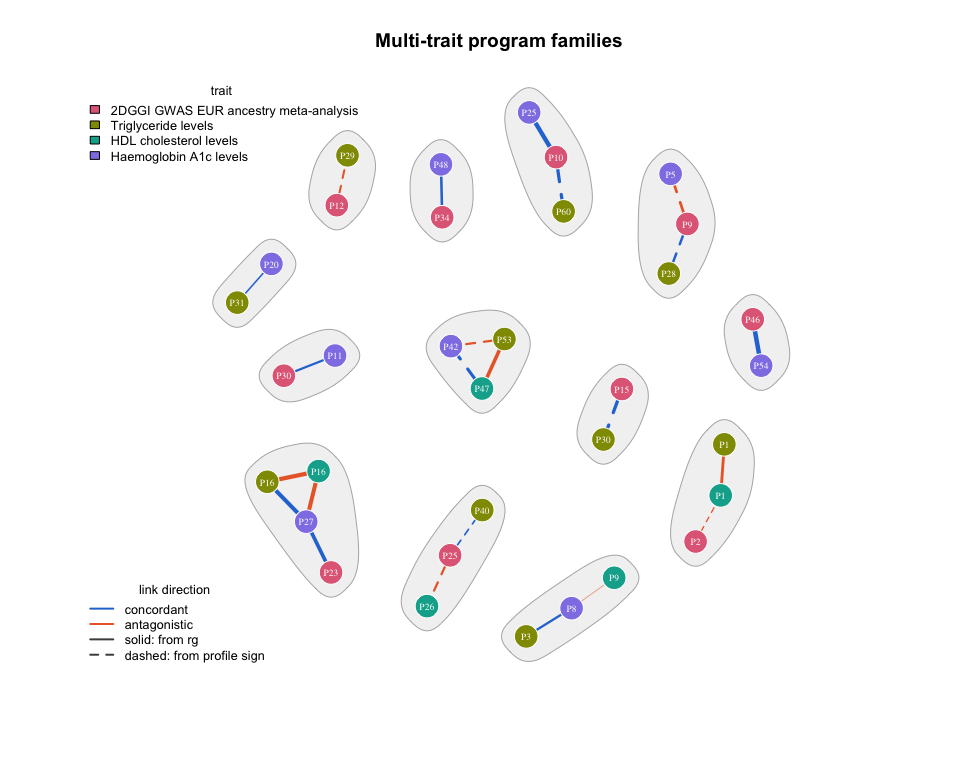

Each node is one program, coloured by trait and labelled with its program number; shaded hulls are the families. Edge width is `|phi_traits|`, the strength of the shared profile; edge colour is the link’s direction – from `rg` where it calls one (solid), otherwise from the sign of the profile congruence (dashed). Programs with no link are not drawn.

## Step 5: Do families recover the same biology?

Annotations play no part in forming a link, so agreement here is **independent corroboration** rather than a restatement of the same evidence. For each family, the high-confidence SNPs of its programs in each trait are pooled and enriched separately, against that trait’s full candidate universe, for trait categories, tissues, and Reactome and KEGG pathways (through the SNPs’ colocalising QTL genes, `enrich_snp_group_pathways()`). If the traits of one family independently surface the same category, tissue or pathway, the family has support beyond the loadings that created it; if they surface nothing in common, it rests on the loadings alone.

One caveat: a SNP set holding a large share of its trait’s SNPs is being compared against a background that is largely itself, so “none” for a dominant program is expected rather than informative.

Trait-category, tissue and pathway enrichment of each family’s high-confidence SNPs, pooled per trait and computed against that trait’s own SNP universe (pathways through the SNPs’ colocalising QTL genes; top Reactome and KEGG term). Matching entries across a family’s traits are held-out support for the family.

| family | trait | programs | n_snps | categories | tissues | reactome | kegg |
| --- | --- | --- | --- | --- | --- | --- | --- |
| family_1 | 2DGGI GWAS EUR ancestry meta-analysis | P23 | 25 | Disease Of Eye And Adnexa (FDR=0.011) | none | none | none |
| family_1 | Haemoglobin A1c levels | P27 | 40 | Anthropometric Measures (FDR=1.8e-07) Metabolic Disease (FDR=0.026) | none | none | none |
| family_1 | HDL cholesterol levels | P16 | 70 | Anthropometric Measures (FDR=9.4e-17) Disease Of Eye And Adnexa (FDR=0.022) Disease Of Circulatory System (FDR=0.027) | none | none | none |
| family_1 | Triglyceride levels | P16 | 73 | Anthropometric Measures (FDR=7.2e-14) | Adipose Subcutaneous (FDR=0.0032) | none | none |
| family_2 | 2DGGI GWAS EUR ancestry meta-analysis | P2 | 9 | Disease Of Circulatory System (FDR=0.011) Metabolic Disease (FDR=0.048) | none | none | none |
| family_2 | HDL cholesterol levels | P1 | 34 | Metabolic Disease (FDR=7.5e-06) Disease Of Circulatory System (FDR=0.0053) | none | Reactome: Plasma lipoprotein assembly | KEGG: Cholesterol metabolism |
| family_2 | Triglyceride levels | P1 | 43 | Metabolic Disease (FDR=0.00081) Disease Of Circulatory System (FDR=0.0018) | none | none | KEGG: Cholesterol metabolism |
| family_3 | 2DGGI GWAS EUR ancestry meta-analysis | P9 | 24 | none | none | none | none |
| family_3 | Haemoglobin A1c levels | P5 | 71 | none | Blood (FDR=0.0025) | none | none |
| family_3 | Triglyceride levels | P28 | 37 | none | none | none | KEGG: Type II diabetes mellitus |
| family_4 | 2DGGI GWAS EUR ancestry meta-analysis | P10 | 28 | Metabolic Disease (FDR=3.2e-06) | none | none | none |
| family_4 | Haemoglobin A1c levels | P25 | 61 | Metabolic Disease (FDR=1.1e-11) | none | none | KEGG: Insulin secretion |
| family_4 | Triglyceride levels | P60 | 18 | Disease Of Genitourinary System (FDR=0) Metabolic Disease (FDR=0.0056) | none | none | KEGG: Maturity onset diabetes of the young |
| family_5 | 2DGGI GWAS EUR ancestry meta-analysis | P25 | 6 | none | none | none | none |
| family_5 | HDL cholesterol levels | P26 | 51 | none | none | Reactome: NR1H3 & NR1H2 regulate gene expression linked to cholesterol transport and efflux | KEGG: Cholesterol metabolism |
| family_5 | Triglyceride levels | P40 | 37 | none | none | none | none |
| family_6 | Haemoglobin A1c levels | P8 | 34 | Anthropometric Measures (FDR=0.00012) Reproductive Measures (FDR=0.035) | none | none | none |
| family_6 | HDL cholesterol levels | P9 | 35 | Anthropometric Measures (FDR=0.0014) Disease Of Eye And Adnexa (FDR=0.041) | none | none | none |
| family_6 | Triglyceride levels | P3 | 36 | Nervous System Disorders (FDR=0) Reproductive Measures (FDR=0.033) Anthropometric Measures (FDR=0.036) | none | none | none |
| family_7 | Haemoglobin A1c levels | P42 | 12 | Disease Of Circulatory System (FDR=0.049) | none | none | none |
| family_7 | HDL cholesterol levels | P47 | 24 | none | none | none | KEGG: SNARE interactions in vesicular transport |
| family_7 | Triglyceride levels | P53 | 27 | Nervous System Disorders (FDR=0) | none | Reactome: Transcriptional Regulation by E2F6 | none |
| family_8 | 2DGGI GWAS EUR ancestry meta-analysis | P12 | 27 | Disease Of Circulatory System (FDR=1e-19) | none | none | none |
| family_8 | Triglyceride levels | P29 | 25 | Nervous System Disorders (FDR=0) Disease Of Circulatory System (FDR=3.2e-15) | none | none | none |
| family_9 | 2DGGI GWAS EUR ancestry meta-analysis | P15 | 51 | Reproductive Measures (FDR=3.5e-08) | none | none | none |
| family_9 | Triglyceride levels | P30 | 50 | Nervous System Disorders (FDR=0) Reproductive Measures (FDR=0.0059) Anthropometric Measures (FDR=0.02) | none | none | none |
| family_10 | 2DGGI GWAS EUR ancestry meta-analysis | P30 | 28 | none | none | Reactome: Glutathione conjugation | KEGG: Glutathione metabolism |
| family_10 | Haemoglobin A1c levels | P11 | 31 | none | none | none | none |
| family_11 | 2DGGI GWAS EUR ancestry meta-analysis | P34 | 34 | none | none | none | none |
| family_11 | Haemoglobin A1c levels | P48 | 32 | none | none | none | none |
| family_12 | 2DGGI GWAS EUR ancestry meta-analysis | P46 | 34 | Disease Of Skin And Subcutaneous Tissue (FDR=0.036) | none | none | none |
| family_12 | Haemoglobin A1c levels | P54 | 52 | Disease Of Circulatory System (FDR=0.0028) Metabolic Disease (FDR=0.0057) Disease Of Eye And Adnexa (FDR=0.011) Anthropometric Measures (FDR=0.011) | none | none | none |
| family_13 | Haemoglobin A1c levels | P20 | 25 | none | none | Reactome: Beta-catenin phosphorylation cascade | none |
| family_13 | Triglyceride levels | P31 | 25 | Disease Of Circulatory System (FDR=0.0038) | none | none | none |